# Performance Comparison: Data.table in R and Pandas in Python

Doris Amoakohene

2024-03-03

# Introduction:

R and Python are two programming languages that have gained immense popularity among data scientists, statisticians, and researchers. In this blog, we will explore two widely used libraries, data.table in R and pandas in Python, which excel in data manipulation and provide versatile functionalities for working with data, focusing on their capabilities for reading, writing, and reshaping data. We will also explain how to graphically demonstrate the time taken by each operation. We will use atime package to compare and visualize the asymptotic performance (time and memory usage) of the different functions mention above. By comparing the asymptotic performance of these packages in thees Languages, we aim to provide insights into their usage and help data scientists make informed choices when it comes to data manipulation and analysis.

In atime::atime() we define the following arguments,

The first argument N is a sequence of data sizes.To explore computational efficiency, we will need to compute time/memory usage for different data sizes(N).

The second argument setup is an expression that will be evaluated for each value in N, to create data of a given size.

seconds.limit may optionally be specified. If an expression is slower than this limit for any data size, then no larger data sizes will be measured.

Lastly, expr.list, which is the list of expressions for which time/memory usage will be measured.

## Various plot

atime::reference_best() : This plot shows the asymptotic reference lines, which defines the estimated asymptotic time and memory complexity. The output and figure will includes violet reference lines, in which the text labels can be interpreted in terms of big O notation (asymptotic time and memory usage).

The predict() function is used to generate predictions based on the atime::reference_best() dataset. The resulting plot illustrates the data size, N, that can be processed within a specific time or memory limit.

## Libraries

```r
library(data.table)
library(reshape2)
library(atime)
library(ggplot2)
library(reticulate)
use_python("C:/Users/amoak/AppData/Local/Programs/Python/Python312/python.exe")
virtualenv_create("fm-proj")
```

```
## virtualenv: fm-proj
```

```r
use_virtualenv("fm-proj", required = F)
```

```python
file_path = 'data.csv'
```

# Example 1: Writing a CSV File with data.table::fwrite() and pandas::to_csv()

## fwrite: fast CSV writer

Data.table provides the fwrite() function for writing data to a file while Pandas offers the to_csv() function for writing data to a CSV file.

## Comparison code

```r
write.colors <- c(
  "data.table::fwrite" = "#D6604D",
  "pandas::to_csv" = "#BF812D"
)

file_path = 'data.csv'
n.rows <- 100
seconds.limit <- 10

atime.write.vary.cols <- atime::atime(
  N = as.integer(10^seq(2, 10, by = 0.2)),
  setup = {
    set.seed(1)
    input.vec <- rnorm(n.rows * N)
    input.mat <- matrix(input.vec, n.rows, N)
    input.df <- data.frame(input.mat)

    pd <- import("pandas")

    input_df_pd <- r_to_py(input.df)



  },
  seconds.limit = seconds.limit,
  "data.table::fwrite" = {
    data.table::fwrite(input.df, tempfile(), showProgress = FALSE)
  },
  "pandas::to_csv" = {

    input_df_pd$to_csv(file_path, index = FALSE)
  }
)
```

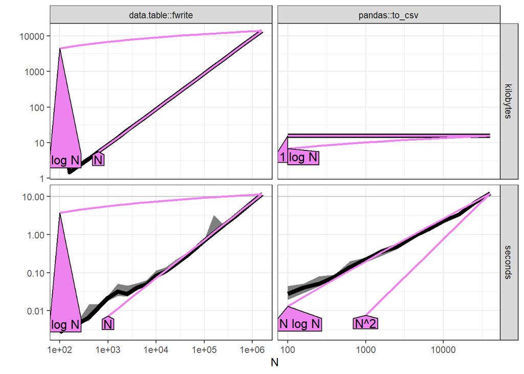

```r
refs.write.vary.cols <- atime::references_best(atime.write.vary.cols)
plot(refs.write.vary.cols)
```

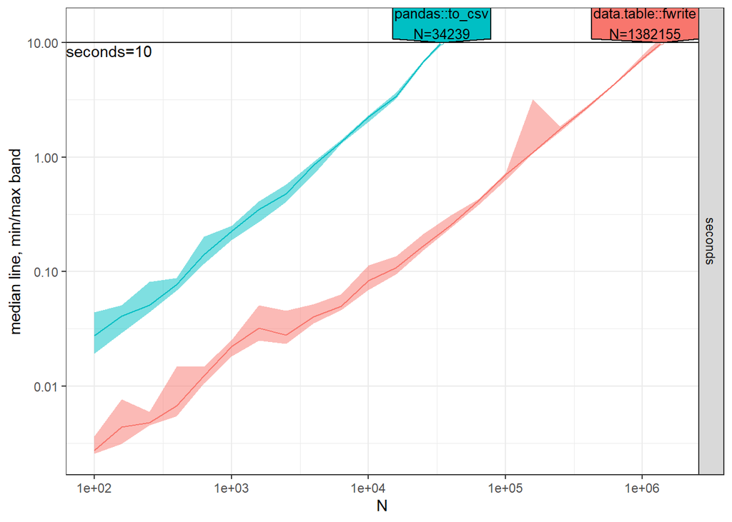

```r
pred.write.vary.cols <- predict(refs.write.vary.cols)
plot(pred.write.vary.cols)
```

```r
gg.write.dt.pd <- plot(pred.write.vary.cols)+
  theme(text=element_text(size=15))+
  ggtitle(sprintf("Write real numbers to CSV, with pandas in Python and data.table in R, %d x N", n.rows))+
  scale_x_log10("N = number of columns to write")+
  scale_y_log10("Computation time (seconds)
median line, min/max band
over 10 timings")+
  facet_null()+
  scale_fill_manual(values=write.colors)+
  scale_color_manual(values=write.colors)
```

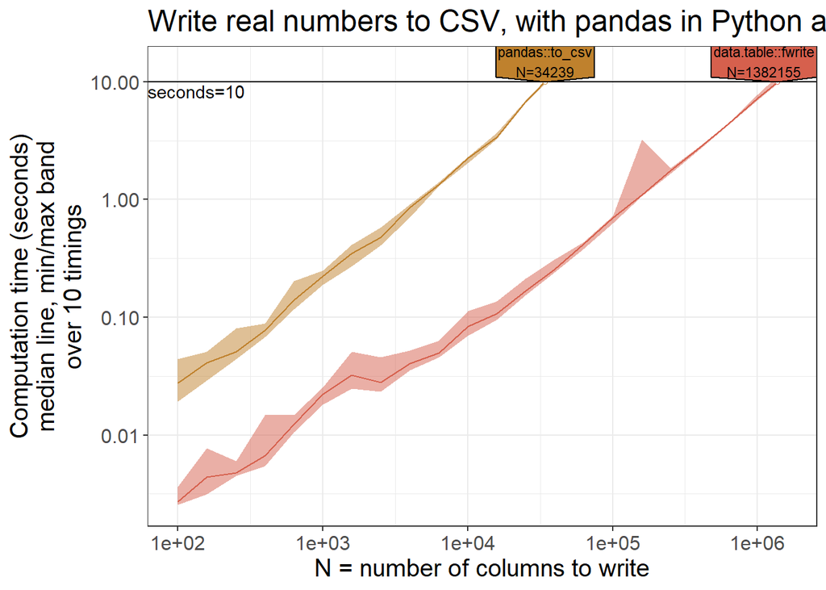

```r
plot(gg.write.dt.pd)
```

The Plot above shows that in terms of writing data, the data.table package in R outperforms Python’s pandas library and particularly useful when dealing with large datasets.